# Investigating Ambiguous Gene Ranges

Kaushal K. Kaslikar

# 1 Purpose

The prior analysis of differentially-enriched peaks revealed genes whose promoters simultaneously contained regions which were differentially enriched for Smad2, differentially enriched for Smad3 and not particularly enriched for either. Such genes were termed ambiguous genes and it was hypothesised that the these regions would be non-overlapping, representing binding sites within the same gene promoter with different affinity for Smad2 or Smad3. This analysis is an attempt to verify that hypothesis.

```r
library(tidyverse)
library(GenomicRanges)
library(ChIPseeker)
library(Gviz)
library(BSgenome.Hsapiens.UCSC.hg38)
```

# 2 Extracting ranges corresponding to ambiguous genes

The relevant objects from the differential binding analysis workspace were previously saved to “Gviz_motif.RData”.

These objects were then loaded into the current workspace for analysis.

```r
load("Gviz_motif.RData")
```

The variable `ambi_ls2_vs_ns3` contained the geneIds for the ambiguous genes in the form of a character vector. These geneIds were used to filter the annotated peak dataframes to obtain range information pertaining only to these ambiguous genes. This information was then used to construct the Grange objects for the peaks differentially-enriched for the respective Smad. This entire process was encapsulated in the form of the function `range_extract`.

```r
range_extract <- function(ambi_list, df){ # ambi_list = ambiguous gene vector, df = annotation dataframe
  ## extracts subset of annotation dataframe corresponding to ambiguous genes
  df_ambi_subset <- df %>%
    filter(geneId %in% ambi_list, str_detect(string = annotation, pattern = "Promoter"))

  # creates ranges based on data from the ambiguous gene data frame subset

  ranges <- GRanges(seqnames = df_ambi_subset$seqnames, ranges = IRanges(start = df_ambi_subset$start, df_ambi_subset$end), strand = df_ambi_subset$strand, GENENAME = df_ambi_subset$GENENAME, SYMBOL = df_ambi_subset$SYMBOL, log10_LR = df_ambi_subset$log10_LR,geneId = df_ambi_subset$geneId, distanceToTSS = df_ambi_subset$distanceToTSS)

  return(ranges)
}
```

Using the function, a GrangesList object `ambi_ranges_ls2_vs_ns3` was created, the first element of which was a Granges object containing peaks enriched for Smad2 and the second element of which was a Granges object containing peaks enriched for Smad3.

```r
ambi_ranges_ls2_vs_ns3 <- GRangesList(range_extract(ambi_list = ambi_ls2_vs_ns3,
                                                    df = df_ls2_vs_ns3_smad2enriched),
                                      range_extract(ambi_list = ambi_ls2_vs_ns3,
                                                    df = df_ls2_vs_ns3_smad3enriched))

# naming granges list elements for easier access and identification

names(ambi_ranges_ls2_vs_ns3) <- c("Smad2", "Smad3")
```

Taking a peek at the reanges in `ambi_ranges_ls2_vs_ns3`.

```r
ambi_ranges_ls2_vs_ns3
```

```
GRangesList object of length 2:
$Smad2
GRanges object with 38 ranges and 5 metadata columns:
       seqnames              ranges strand |                          GENENAME       SYMBOL
          <Rle>           <IRanges>  <Rle> |                       <character>  <character>
   [1]    chr10   79069938-79070582      * | zinc finger MIZ-type containing 1        ZMIZ1
   [2]    chr19   36301704-36302075      * |      uncharacterized LOC100134317 LOC100134317
   [3]    chr19   36304272-36304591      * |      uncharacterized LOC100134317 LOC100134317
   [4]    chr19   36306562-36307036      * |      uncharacterized LOC100134317 LOC100134317
   [5]    chr19   36309288-36309623      * |      uncharacterized LOC100134317 LOC100134317
   ...      ...                 ...    ... .                               ...          ...
  [34]    chr21     8441594-8442699      * |            RNA, 5.8S ribosomal N4    RNA5-8SN4
  [35]    chr21     8986603-8988212      * |                   microRNA 3648-1    MIR3648-1
  [36]     chr6   41546541-41547097      * |                   forkhead box P4        FOXP4
  [37]     chr7 139777348-139777557      * |          thromboxane A synthase 1       TBXAS1
  [38]     chr9 136799381-136799598      * | coiled-coil domain containing 183      CCDC183
             log10_LR      geneId distanceToTSS
            <numeric> <character>     <numeric>
   [1] 21517838581760       57178           972
   [2] 54173047455744   100134317         -2489
   [3] 34442288562176   100134317             0
   [4] 24612870029312   100134317           -48
   [5] 42949945589760   100134317             0
   ...            ...         ...           ...
  [34]  9773741244416   109864274          1771
  [35]  6879666241536   100500862             0
  [36] 22045882580992      116113             0
  [37] 51581034692608        6916           201
  [38] 81669977538560       84960             0
  -------
  seqinfo: 24 sequences from an unspecified genome; no seqlengths

$Smad3
GRanges object with 49 ranges and 5 metadata columns:
       seqnames              ranges strand |                                    GENENAME
          <Rle>           <IRanges>  <Rle> |                                 <character>
   [1]     chr1   16643684-16643930      * |                          CROCC pseudogene 2
   [2]    chr10   79276409-79276662      * |           zinc finger MIZ-type containing 1
   [3]    chr15 101976527-101976792      * |               DEAD/H-box helicase 11 like 9
   [4]    chr15 101978742-101979097      * |               DEAD/H-box helicase 11 like 9
   [5]    chr17   43233809-43234250      * |                     RNA, U2 small nuclear 1
   ...      ...                 ...    ... .                                         ...
  [45]     chr7 139955088-139955318      * |                    thromboxane A synthase 1
  [46]     chr8   85663594-85664128      * |                    REXO1 like 2, pseudogene
  [47]     chr8   85826320-85826561      * |                    REXO1 like 2, pseudogene
  [48]     chr9         12047-12269      * |               DEAD/H-box helicase 11 like 5
  [49]     chr9   61856919-61857284      * | family with sequence similarity 27 member C
            SYMBOL        log10_LR      geneId distanceToTSS
       <character>       <numeric> <character>     <numeric>
   [1]     CROCCP2  47076142481408       84809           742
   [2]       ZMIZ1 168444322381824       57178          -517
   [3]     DDX11L9  40680894234624   100288486          1999
   [4]     DDX11L9  36919303995392   100288486             0
   [5]      RNU2-1  25976956256256        6066             0
   ...         ...             ...         ...           ...
  [45]      TBXAS1  48126949851136        6916          1653
  [46]    REXO1L2P  26166108880896   100288527           -97
  [47]    REXO1L2P  50612376961024   100288527          1381
  [48]     DDX11L5  79855085420544   100287596             0
  [49]      FAM27C  34332601221120   100132948          2703
  -------
  seqinfo: 24 sequences from an unspecified genome; no seqlengths
```

# 3 Analysis of ambiguous gene ranges

First, the Granges corresponding to Smad2 and Smad3 respectively were compared to each other to find any overlapping ranges. None were found, strengthening the hypothesis that the differential binding regions for each Smad within a gene promoter were non-overlapping.

```r
findOverlaps(query = ambi_ranges_ls2_vs_ns3$Smad2, subject = ambi_ranges_ls2_vs_ns3$Smad3)
```

```
Hits object with 0 hits and 0 metadata columns:
   queryHits subjectHits
   <integer>   <integer>
  -------
  queryLength: 38 / subjectLength: 49
```

## 3.1 Plotting ranges

```r
seqnames(ambi_ranges_ls2_vs_ns3)
```

```
RleList of length 2
$Smad2
factor-Rle of length 38 with 6 runs
  Lengths:     1     7    27     1     1     1
  Values : chr10 chr19 chr21  chr6  chr7  chr9
Levels(24): chr1 chr10 chr11 chr12 chr13 chr14 chr15 ... chr5 chr6 chr7 chr8 chr9 chrX chrY

$Smad3
factor-Rle of length 49 with 10 runs
  Lengths:     1     1     2    11    25     2     2     1     2     2
  Values :  chr1 chr10 chr15 chr17 chr21  chr5  chr6  chr7  chr8  chr9
Levels(24): chr1 chr10 chr11 chr12 chr13 chr14 chr15 ... chr5 chr6 chr7 chr8 chr9 chrX chrY
```

```r
# creating annotation tracks for Gviz from individual grange list elements

smad2_track <- AnnotationTrack(range = ambi_ranges_ls2_vs_ns3$Smad2, name="Smad2")

smad3_track <- AnnotationTrack(range = ambi_ranges_ls2_vs_ns3$Smad3, name="Smad3")


# creating genome axis track

gtrack <- GenomeAxisTrack()
```

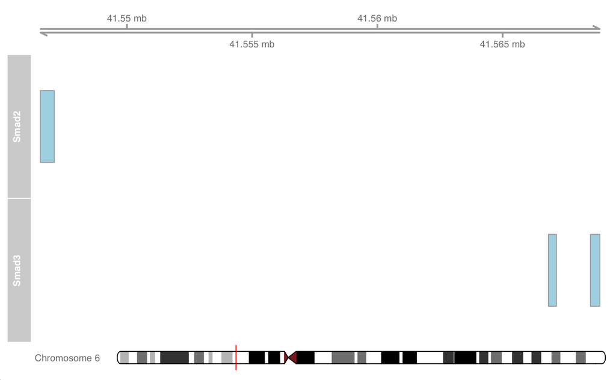

```r
plotTracks(trackList = c(gtrack, smad2_track, smad3_track, IdeogramTrack(chromosome = "chr6", genome = "hg38")), chromosome = "chr6")
```

The ranges on chromosome 6 for Smad2 and Smad 3 were a fair distance apart, but still lay within the promoter of one gene, `forkhead box P4`.

```r
ambi_ranges_ls2_vs_ns3$Smad2[seqnames(ambi_ranges_ls2_vs_ns3$Smad2) == "chr6"] %>%
  mcols() %>%
  as_tibble() %>%
  mutate(TF = "Smad2") %>%
full_join(x = ., y = (ambi_ranges_ls2_vs_ns3$Smad3[seqnames(ambi_ranges_ls2_vs_ns3$Smad3) == "chr6"] %>% mcols() %>% as_tibble()) %>% mutate(TF = "Smad3")) %>%
    dplyr::select(GENENAME, SYMBOL, TF, distanceToTSS, everything()) %>%
  arrange(GENENAME, distanceToTSS)
```

| GENENAME | SYMBOL | TF | distanceToTSS | log10_LR | geneId |
| --- | --- | --- | --- | --- | --- |
| forkhead box P4 | FOXP4 | Smad3 | -1293 | 2.882470e+13 | 116113 |
| forkhead box P4 | FOXP4 | Smad2 | 0 | 2.204588e+13 | 116113 |
| forkhead box P4 | FOXP4 | Smad3 | 1079 | 3.756250e+13 | 116113 |

```r
  # knitr::kable()
```

The ranges on chromosome 9 for Smad2 and Smad3 were in completely distinct chromosome regions which were a large distance apart, and were located in promoters of completely different genes.

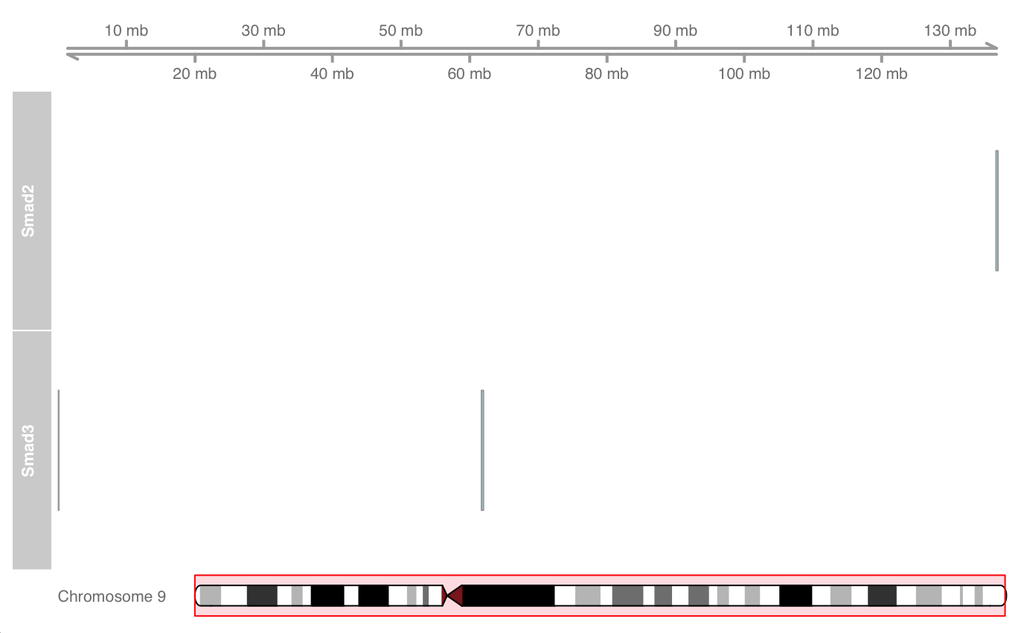

```r
plotTracks(trackList = c(gtrack, smad2_track, smad3_track, IdeogramTrack(chromosome = "chr9", genome = "hg38")), chromosome = "chr9")
```

```r
ambi_ranges_ls2_vs_ns3$Smad2[seqnames(ambi_ranges_ls2_vs_ns3$Smad2) == "chr9"] %>%
  mcols() %>%
  as_tibble() %>%
  mutate(TF = "Smad2") %>%
  full_join(
    x = ., y = (
    ambi_ranges_ls2_vs_ns3$Smad3[seqnames(ambi_ranges_ls2_vs_ns3$Smad3) == "chr9"] %>%
                          mcols() %>%
                          as_tibble()
                        ) %>%
              mutate(TF = "Smad3")
    ) %>%
  dplyr::select(GENENAME, SYMBOL, TF, distanceToTSS, everything()) %>%
  arrange(GENENAME, distanceToTSS)
```

| GENENAME | SYMBOL | TF | distanceToTSS | log10_LR | geneId |
| --- | --- | --- | --- | --- | --- |
| coiled-coil domain containing 183 | CCDC183 | Smad2 | 0 | 8.166998e+13 | 84960 |
| DEAD/H-box helicase 11 like 5 | DDX11L5 | Smad3 | 0 | 7.985509e+13 | 100287596 |
| family with sequence similarity 27 member C | FAM27C | Smad3 | 2703 | 3.433260e+13 | 100132948 |

```r
NA
NA
NA
```

The ranges on Chromosome 10 were located far apart within the promoter of the same gene, `zinc finger MIZ-type containing 1`.

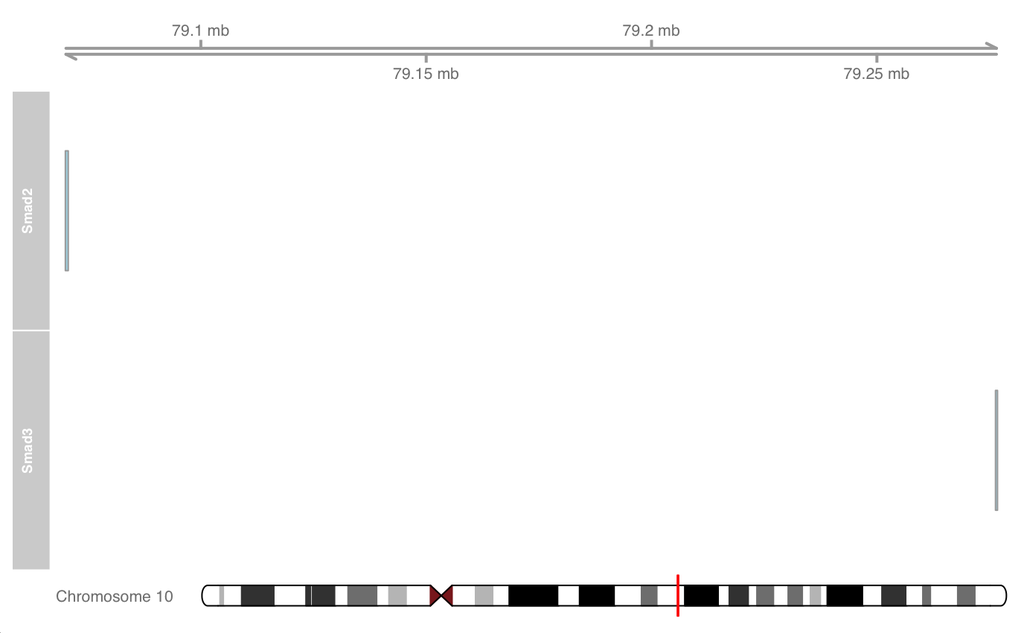

```r
plotTracks(trackList = c(gtrack, smad2_track, smad3_track, IdeogramTrack(chromosome = "chr10", genome = "hg38")), chromosome = "chr10")
```

```r
ambi_ranges_ls2_vs_ns3$Smad2[seqnames(ambi_ranges_ls2_vs_ns3$Smad2) == "chr10"] %>%
  mcols() %>%
  as_tibble() %>%
  mutate(TF = "Smad2") %>%
  full_join(x = ., y = (ambi_ranges_ls2_vs_ns3$Smad3[seqnames(ambi_ranges_ls2_vs_ns3$Smad3) == "chr10"] %>% mcols() %>% as_tibble()) %>% mutate(TF = "Smad3")) %>%
  dplyr::select(GENENAME, SYMBOL, TF, distanceToTSS, everything()) %>%
  arrange(GENENAME, distanceToTSS)
```

| GENENAME | SYMBOL | TF | distanceToTSS | log10_LR | geneId |
| --- | --- | --- | --- | --- | --- |
| zinc finger MIZ-type containing 1 | ZMIZ1 | Smad3 | -517 | 1.684443e+14 | 57178 |
| zinc finger MIZ-type containing 1 | ZMIZ1 | Smad2 | 972 | 2.151784e+13 | 57178 |

```r
  # knitr::kable()
```

The ranges within Chromosome 21 came the closest to overlapping. However, upon zooming in, closer inspection revealed that these regions of Smad2 and Smad3 differential enrichment were adjacent to each other, with peaks from the two Smads occurring in an alternating fashion.

In addition, there was also a Smad3-exclusive set of ranges beyond 9.5 mb.

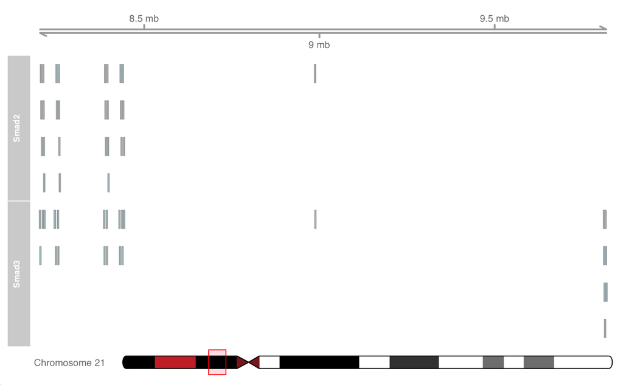

```r
plotTracks(trackList = c(gtrack, smad2_track, smad3_track, IdeogramTrack(chromosome = "chr21", genome = "hg38")), chromosome = "chr21")
```

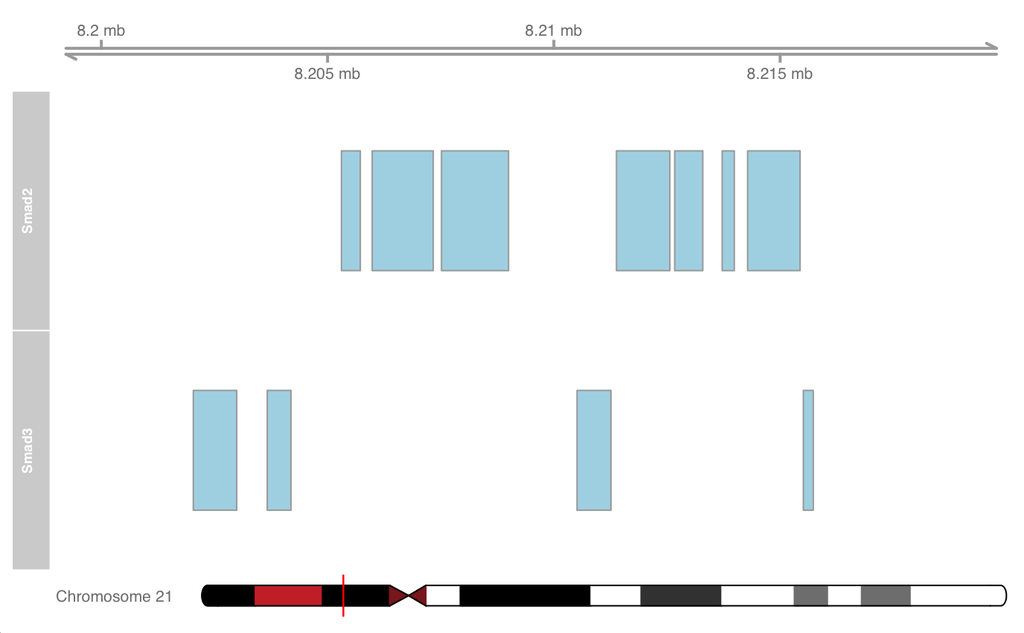

```r
plotTracks(trackList = c(gtrack, smad2_track, smad3_track, IdeogramTrack(chromosome = "chr21", genome = "hg38")), chromosome = "chr21", from = 8.199*10^6, to = 8.22*10^6)
```

```r
NA
NA
NA
```

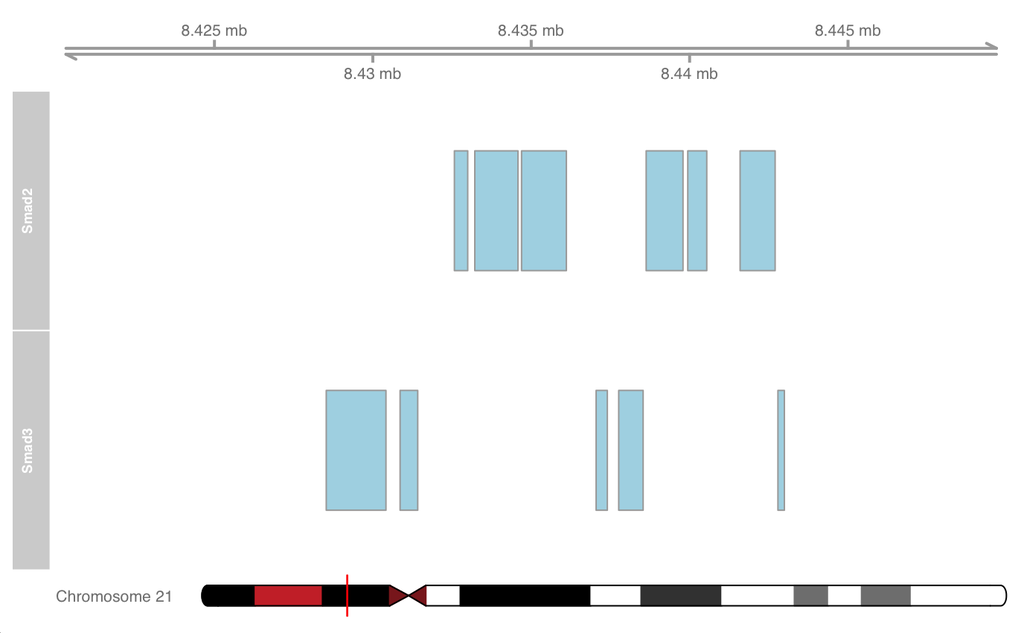

```r
plotTracks(trackList = c(gtrack, smad2_track, smad3_track, IdeogramTrack(chromosome = "chr21", genome = "hg38")), chromosome = "chr21", from = 8.42*10^6, to = 8.45*10^6)
```

```r
ambi_ranges_ls2_vs_ns3$Smad2[seqnames(ambi_ranges_ls2_vs_ns3$Smad2) == "chr21"] %>%
  mcols() %>%
  as_tibble() %>%
  mutate(TF = "Smad2") %>%
  full_join(x = ., y = (ambi_ranges_ls2_vs_ns3$Smad3[seqnames(ambi_ranges_ls2_vs_ns3$Smad3) == "chr21"] %>% mcols() %>% as_tibble()) %>% mutate(TF = "Smad3")) %>%
  dplyr::select(GENENAME, SYMBOL, TF, distanceToTSS, everything()) %>%
  arrange(GENENAME, distanceToTSS)
```

| GENENAME | SYMBOL | TF | distanceToTSS | log10_LR | geneId |
| --- | --- | --- | --- | --- | --- |
| long intergenic non-protein coding RNA 1667 | LINC01667 | Smad3 | -1920 | 2.182275e+13 | 441058 |
| long intergenic non-protein coding RNA 1667 | LINC01667 | Smad3 | -860 | 4.099025e+13 | 441058 |
| long intergenic non-protein coding RNA 1667 | LINC01667 | Smad3 | -811 | 3.743207e+13 | 441058 |
| long intergenic non-protein coding RNA 1667 | LINC01667 | Smad3 | 278 | 5.472303e+13 | 441058 |
| long intergenic non-protein coding RNA 1667 | LINC01667 | Smad3 | 347 | 8.983698e+13 | 441058 |
| long intergenic non-protein coding RNA 1667 | LINC01667 | Smad3 | 348 | 3.071350e+13 | 441058 |
| long intergenic non-protein coding RNA 1667 | LINC01667 | Smad3 | 702 | 5.363401e+13 | 441058 |
| microRNA 3648-1 | MIR3648-1 | Smad2 | 0 | 7.575851e+12 | 100500862 |
| microRNA 3648-1 | MIR3648-1 | Smad2 | 0 | 6.879666e+12 | 100500862 |
| microRNA 3648-1 | MIR3648-1 | Smad3 | 1318 | 3.500142e+13 | 100500862 |

[output cut: 42 more lines]

```r
  # knitr::kable()
```

# 4 Exporting ambiguous gene ranges to BED format for motif discovery by HOMER

Since HOMER requires a unique peak ID for each peak in the BED file, here I attempted to give a unique peak ID by using the gene which the peak lay in, as well as its order within all the peaks within the same gene. For instance, the first peak within the promoter of gene “microRNA 3648-1” would be labelled “microRNA 3648-1–1”. The reason for using the double-hyphen is because some gene names (such as the one mentioned) already contain single hyphens; the use of the double-hyphen will prevent confusion as to whether the number at the end of the peak ID is part of the gene name or the peak ID. The double-hyphen will always designate the number as being part of a peak ID.

```r
df_ambi_ranges_ls2_vs_ns3_smad2 <- ambi_ranges_ls2_vs_ns3$Smad2 %>%
  as.data.frame() %>%
  as_tibble() ## data frame created from ambiguous gene ranges

## creating column of unique identifiers for individual ranges based on annotated gene names

vs2 <- df_ambi_ranges_ls2_vs_ns3_smad2 %>%
  dplyr::select(GENENAME) %>%
  unlist(use.names = FALSE)

vs2 %>% head()
```

```
[1] "zinc finger MIZ-type containing 1" "uncharacterized LOC100134317"
[3] "uncharacterized LOC100134317"      "uncharacterized LOC100134317"
[5] "uncharacterized LOC100134317"      "uncharacterized LOC284412"
```

```r
unique_peak_id_s2 <- vector(mode = "character", length = 0) # unique peak ids for smad2

for(i in seq_along(vs2)){
  unique_peak_id_s2 <- append(unique_peak_id_s2, paste(vs2[i], sum(vs2[1:i] == vs2[i]), sep = "--"))
}

unique_peak_id_s2
```

```
 [1] "zinc finger MIZ-type containing 1--1" "uncharacterized LOC100134317--1"
 [3] "uncharacterized LOC100134317--2"      "uncharacterized LOC100134317--3"
 [5] "uncharacterized LOC100134317--4"      "uncharacterized LOC284412--1"
 [7] "uncharacterized LOC284412--2"         "uncharacterized LOC284412--3"
 [9] "microRNA 6724-1--1"                   "microRNA 6724-1--2"
[11] "microRNA 3648-1--1"                   "RNA, 5.8S ribosomal N4--1"
[13] "RNA, 5.8S ribosomal N4--2"            "RNA, 5.8S ribosomal N4--3"
[15] "RNA, 5.8S ribosomal N4--4"            "microRNA 6724-1--3"
[17] "microRNA 6724-1--4"                   "RNA, 5.8S ribosomal N4--5"
[19] "RNA, 5.8S ribosomal N4--6"            "RNA, 5.8S ribosomal N4--7"
[21] "RNA, 5.8S ribosomal N4--8"            "microRNA 6724-1--5"
[23] "microRNA 6724-1--6"                   "microRNA 6724-1--7"
[25] "RNA, 5.8S ribosomal N4--9"            "RNA, 5.8S ribosomal N4--10"
[27] "RNA, 5.8S ribosomal N4--11"           "RNA, 5.8S ribosomal N4--12"
[29] "microRNA 6724-1--8"                   "microRNA 6724-1--9"
[31] "microRNA 6724-1--10"                  "RNA, 5.8S ribosomal N4--13"
[33] "RNA, 5.8S ribosomal N4--14"           "RNA, 5.8S ribosomal N4--15"
[35] "microRNA 3648-1--2"                   "forkhead box P4--1"
[37] "thromboxane A synthase 1--1"          "coiled-coil domain containing 183--1"
```

```r
df_ambi_ranges_ls2_vs_ns3_smad2 <- df_ambi_ranges_ls2_vs_ns3_smad2 %>%
  mutate(unique_peak_id = unique_peak_id_s2, blank = "", strand = ".")

df_ambi_ranges_ls2_vs_ns3_smad2 %>%
  dplyr::select(seqnames, start, end, width, unique_peak_id, strand, everything())
```

| seqnames | start | end | width | unique_peak_id | strand | GENENAME | SYMBOL | log10_LR | geneId | distanceToTSS | blank |
| --- | --- | --- | --- | --- | --- | --- | --- | --- | --- | --- | --- |
| chr10 | 79069938 | 79070582 | 645 | zinc finger MIZ-type containing 1--1 | . | zinc finger MIZ-type containing 1 | ZMIZ1 | 2.151784e+13 | 57178 | 972 |  |
| chr19 | 36301704 | 36302075 | 372 | uncharacterized LOC100134317--1 | . | uncharacterized LOC100134317 | LOC100134317 | 5.417305e+13 | 100134317 | -2489 |  |
| chr19 | 36304272 | 36304591 | 320 | uncharacterized LOC100134317--2 | . | uncharacterized LOC100134317 | LOC100134317 | 3.444229e+13 | 100134317 | 0 |  |
| chr19 | 36306562 | 36307036 | 475 | uncharacterized LOC100134317--3 | . | uncharacterized LOC100134317 | LOC100134317 | 2.461287e+13 | 100134317 | -48 |  |
| chr19 | 36309288 | 36309623 | 336 | uncharacterized LOC100134317--4 | . | uncharacterized LOC100134317 | LOC100134317 | 4.294995e+13 | 100134317 | 0 |  |
| chr19 | 37271473 | 37271986 | 514 | uncharacterized LOC284412--1 | . | uncharacterized LOC284412 | LOC284412 | 2.501261e+13 | 284412 | 0 |  |
| chr19 | 37274256 | 37274499 | 244 | uncharacterized LOC284412--2 | . | uncharacterized LOC284412 | LOC284412 | 7.383861e+13 | 284412 | -2738 |  |
| chr19 | 37301625 | 37302189 | 565 | uncharacterized LOC284412--3 | . | uncharacterized LOC284412 | LOC284412 | 2.369327e+13 | 284412 | 2151 |  |
| chr21 | 8205306 | 8205723 | 418 | microRNA 6724-1--1 | . | microRNA 6724-1 | MIR6724-1 | 3.227676e+13 | 102465433 | 0 |  |
| chr21 | 8205986 | 8207334 | 1349 | microRNA 6724-1--2 | . | microRNA 6724-1 | MIR6724-1 | 8.665946e+12 | 102465433 | 671 |  |

[output cut: 28 more lines]

```r
###

df_ambi_ranges_ls2_vs_ns3_smad3 <- ambi_ranges_ls2_vs_ns3$Smad3 %>%
  as.data.frame() %>%
  as_tibble() ## data frame created from ambiguous gene ranges

## creating column of unique identifiers for individual ranges based on annotated gene names

vs3 <- df_ambi_ranges_ls2_vs_ns3_smad3 %>% # vector of gene names corresponding to smad3 peaks
  dplyr::select(GENENAME) %>%
  unlist(use.names = FALSE)

vs3 %>% head()
```

```
[1] "CROCC pseudogene 2"                "zinc finger MIZ-type containing 1"
[3] "DEAD/H-box helicase 11 like 9"     "DEAD/H-box helicase 11 like 9"
[5] "RNA, U2 small nuclear 1"           "RNA, U2 small nuclear 1"
```

```r
unique_peak_id_s3 <- vector(mode = "character", length = 0) # unique peak ids for smad3

for(i in seq_along(vs3)){
  unique_peak_id_s3 <- append(unique_peak_id_s3, paste(vs3[i], sum(vs3[1:i] == vs3[i]), sep = "--"))
}

unique_peak_id_s3 %>% head()
```

```
[1] "CROCC pseudogene 2--1"                "zinc finger MIZ-type containing 1--1"
[3] "DEAD/H-box helicase 11 like 9--1"     "DEAD/H-box helicase 11 like 9--2"
[5] "RNA, U2 small nuclear 1--1"           "RNA, U2 small nuclear 1--2"
```

```r
df_ambi_ranges_ls2_vs_ns3_smad3 <- df_ambi_ranges_ls2_vs_ns3_smad3 %>%
  mutate(unique_peak_id = unique_peak_id_s3, blank = "", strand = ".")

df_ambi_ranges_ls2_vs_ns3_smad3 %>%
  dplyr::select(seqnames, start, end, unique_peak_id, width, strand, everything())
```

| seqnames | start | end | unique_peak_id | width | strand | GENENAME | SYMBOL | log10_LR | geneId | distanceToTSS | blank |
| --- | --- | --- | --- | --- | --- | --- | --- | --- | --- | --- | --- |
| chr1 | 16643684 | 16643930 | CROCC pseudogene 2--1 | 247 | . | CROCC pseudogene 2 | CROCCP2 | 4.707614e+13 | 84809 | 742 |  |
| chr10 | 79276409 | 79276662 | zinc finger MIZ-type containing 1--1 | 254 | . | zinc finger MIZ-type containing 1 | ZMIZ1 | 1.684443e+14 | 57178 | -517 |  |
| chr15 | 101976527 | 101976792 | DEAD/H-box helicase 11 like 9--1 | 266 | . | DEAD/H-box helicase 11 like 9 | DDX11L9 | 4.068089e+13 | 100288486 | 1999 |  |
| chr15 | 101978742 | 101979097 | DEAD/H-box helicase 11 like 9--2 | 356 | . | DEAD/H-box helicase 11 like 9 | DDX11L9 | 3.691930e+13 | 100288486 | 0 |  |
| chr17 | 43233809 | 43234250 | RNA, U2 small nuclear 1--1 | 442 | . | RNA, U2 small nuclear 1 | RNU2-1 | 2.597696e+13 | 6066 | 0 |  |
| chr17 | 43239702 | 43239959 | RNA, U2 small nuclear 1--2 | 258 | . | RNA, U2 small nuclear 1 | RNU2-1 | 6.378957e+13 | 6066 | 152 |  |
| chr17 | 43243869 | 43244078 | RNA, U2 small nuclear 1--3 | 210 | . | RNA, U2 small nuclear 1 | RNU2-1 | 8.166998e+13 | 6066 | 1786 |  |
| chr17 | 43245836 | 43246120 | RNA, U2 small nuclear 1--4 | 285 | . | RNA, U2 small nuclear 1 | RNU2-1 | 4.244267e+13 | 6066 | 0 |  |
| chr17 | 43251548 | 43252225 | RNA, U2 small nuclear 1--5 | 678 | . | RNA, U2 small nuclear 1 | RNU2-1 | 2.428026e+13 | 6066 | 0 |  |
| chr17 | 43264527 | 43264732 | RNA, U2 small nuclear 1--6 | 206 | . | RNA, U2 small nuclear 1 | RNU2-1 | 5.336850e+13 | 6066 | 2091 |  |

[output cut: 39 more lines]

```r
### writing bed files

write_tsv(x = df_ambi_ranges_ls2_vs_ns3_smad2 %>% dplyr::select(seqnames, start, end, unique_peak_id, blank, strand), path = "ambi_ranges_ls2_vs_ns3_Smad2.bed" , col_names = FALSE)

write_tsv(x = df_ambi_ranges_ls2_vs_ns3_smad3 %>% dplyr::select(seqnames, start, end, unique_peak_id, blank, strand), path = "ambi_ranges_ls2_vs_ns3_Smad3.bed", col_names = FALSE)
```